# Practical Machine Learning Course Project

Jose Elgenedy

May 2018

## Executive Summary

This project is part of the Practical Machine Learning course on Coursera, a part of the Johns Hopkins Data Science Specialization.

Using devices such as Jawbone Up, Nike FuelBand, and Fitbit it is now possible to collect a large amount of data about personal activity relatively inexpensively.

Data was collect by 6 participants who were asked to peform one set of 10 repetitions of the Unilateral Dumbbell Biceps Curl in five different fashions:

```
+ exactly according to the specification (Class A),
+ throwing the elbows to the front (Class B),
+ lifting the dumbbell only halfway (Class C),
+ lowering the dumbbell only halfway (Class D) and
+ throwing the hips to the front (Class E)
```

The goal of this project is to predict to which class each observation belongs to using data from accelerometers on these devices

For moe information about this data, pelase visit: http://web.archive.org/web/20161224072740/http:/groupware.les.inf.puc-rio.br/har

## Methodological approach

The objective is to predict the variable *classe* which is un unordered factor variable with 5 levels (as described above).

Given the sample size in the training set (19622), we can divide it into a sub-training and sub-testing sets to allow cross-validation.

Two different models wil be used: decision tree and random forest. Both algorithms are known for theis ability in detecting features for classification.

Cross-validation will be conducted by randomly subsampling without replacement. Sub-training will be assigned 75% of the original training set while the sub-testing 25%. Models will be fitted on the sub-training set and tested individually on the sub-testing set. The most accurate model will be used in the original testing setand will be considered our final model.

The expected out-of-sample error will correspond to the quantity: 1-accuracy in the cross-validation data. Accuracy is the proportion of correct classified observation over the total sample in the subTesting data set. Expected accuracy is the expected accuracy in the out-of-sample data set (i.e. original testing data set). Thus, the expected value of the out-of-sample error will correspond to the expected number of missclassified observations/total observations in the Test data set, which is the quantity: 1-accuracy found from the cross-validation data set.

For reproducibility, the random number generator seed used was 23058

```r
set.seed(23058)
```

## Requirements

Analysis performed under R 3.4.2, in Windows 10, 64b version.

Packages needed:

```
+ caret
+ randomForest
+ rpart
+ rpart.plot
```

```r
library(caret)
library(randomForest)
```

```r
library(rpart)
library(rpart.plot)
```

## Data loading and clean up

The datasets used in this project were:

Training dataset: https://d396qusza40orc.cloudfront.net/predmachlearn/pml-training.csv

Test dataset: https://d396qusza40orc.cloudfront.net/predmachlearn/pml-testing.csv

### Loading data

We start by loading the data into R. In both datasets, NA’s are coded in three different ways: DIV/0!, NA or an empty string. All of them will be coded as NA:

```r
trainset<-read.csv('pml-training.csv', na.strings = c("NA", "#DIV/0!", ""))
testset<-read.csv('pml-testing.csv', na.strings = c("NA", "#DIV/0!", ""))

dim (trainset)
```

```
## [1] 19622   160
```

```r
dim (testset)
```

```
## [1]  20 160
```

### Clean up data

So, the training set has 19622 observations and the testing set has 20. Both have 160 Variables.

The first 7 variables are irrelevant to this study (X - a sequencial number, user_name, raw_timestamp_part_1, raw_timestamp_part_,2 cvtd_timestamp, new_window, and num_window). So I can remove them.

```r
trainset   <-trainset[,-c(1:7)]
testset <-testset[,-c(1:7)]
```

I will also remove columns that only have NA’s:

```r
trainset   <-trainset[,colSums(is.na(trainset)) == 0]
testset <-testset[,colSums(is.na(testset)) == 0]
```

which gets us to this new dimensions:

```r
dim (trainset)
```

```
## [1] 19622    53
```

```r
dim (testset)
```

```
## [1] 20 53
```

And we get down to 53 variables.

## Data preparation, model fitting and prediction

### Partitioning training data, 75% for subtrain and 25% for subtest:

```r
subsample <- createDataPartition(y=trainset$classe, p=0.75, list=FALSE)
subtrain <- trainset[subsample, ]
subtest <- trainset[-subsample, ]
```

### Fiting firt model - Random Forest:

```r
forestModel<-randomForest(classe ~ ., data=subtrain, method="class")
```

Predicting with Random Forest:

```r
forestPrediction<-predict(forestModel, subtest, type = "class")
```

Testing results of random forest using subtest

```r
confusionMatrix(forestPrediction, subtest$classe)
```

```
## Confusion Matrix and Statistics
##
##           Reference
## Prediction    A    B    C    D    E
##          A 1395    2    0    0    0
##          B    0  946    3    0    0
##          C    0    1  852    8    1
##          D    0    0    0  795    2
##          E    0    0    0    1  898
##
## Overall Statistics
##
##                Accuracy : 0.9963
##                  95% CI : (0.9942, 0.9978)
##     No Information Rate : 0.2845
##     P-Value [Acc > NIR] : < 2.2e-16
##
##                   Kappa : 0.9954
##  Mcnemar's Test P-Value : NA
##
## Statistics by Class:
##
##                      Class: A Class: B Class: C Class: D Class: E
## Sensitivity            1.0000   0.9968   0.9965   0.9888   0.9967
## Specificity            0.9994   0.9992   0.9975   0.9995   0.9998
## Pos Pred Value         0.9986   0.9968   0.9884   0.9975   0.9989
## Neg Pred Value         1.0000   0.9992   0.9993   0.9978   0.9993
## Prevalence             0.2845   0.1935   0.1743   0.1639   0.1837
## Detection Rate         0.2845   0.1929   0.1737   0.1621   0.1831
## Detection Prevalence   0.2849   0.1935   0.1758   0.1625   0.1833
## Balanced Accuracy      0.9997   0.9980   0.9970   0.9942   0.9982
```

### Fiting second model - Decision tree:

```r
treeModel<-rpart(classe ~ ., data=subtrain, method="class")
```

Predicting with Decision tree:

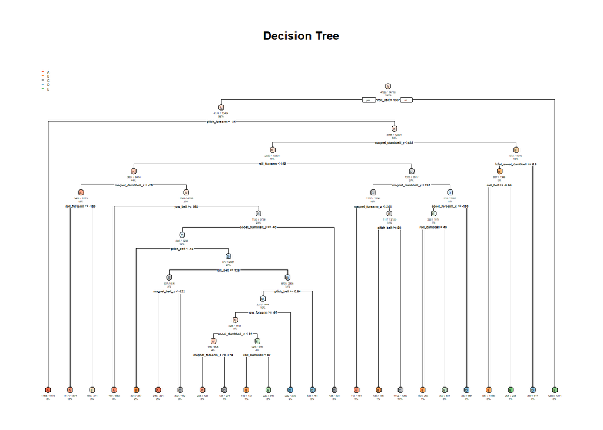

```r
treePrediction<-predict(treeModel, subtest, type = "class")
rpart.plot(treeModel, main="Decision Tree", extra=102, under=TRUE, faclen=0)
```

Testing results of decision tree using subtest

```r
confusionMatrix(treePrediction, subtest$classe)
```

```
## Confusion Matrix and Statistics
##
##           Reference
## Prediction    A    B    C    D    E
##          A 1246  132   15   43   11
##          B   48  570   42   73   71
##          C   31  104  699  113  107
##          D   47   66   47  512   54
##          E   23   77   52   63  658
##
## Overall Statistics
##
##                Accuracy : 0.7514
##                  95% CI : (0.7391, 0.7635)
##     No Information Rate : 0.2845
##     P-Value [Acc > NIR] : < 2.2e-16
##
##                   Kappa : 0.6853
##  Mcnemar's Test P-Value : < 2.2e-16
##
## Statistics by Class:
##
##                      Class: A Class: B Class: C Class: D Class: E
## Sensitivity            0.8932   0.6006   0.8175   0.6368   0.7303
## Specificity            0.9427   0.9408   0.9123   0.9478   0.9463
## Pos Pred Value         0.8611   0.7090   0.6632   0.7052   0.7537
## Neg Pred Value         0.9569   0.9076   0.9595   0.9301   0.9397
## Prevalence             0.2845   0.1935   0.1743   0.1639   0.1837
## Detection Rate         0.2541   0.1162   0.1425   0.1044   0.1342
## Detection Prevalence   0.2951   0.1639   0.2149   0.1480   0.1780
## Balanced Accuracy      0.9180   0.7707   0.8649   0.7923   0.8383
```

## Final run

Finally, we’ll run our model in the original test set:

```r
finalPrediction<-predict(forestModel, testset, type="class")
finalPrediction
```

```
##  1  2  3  4  5  6  7  8  9 10 11 12 13 14 15 16 17 18 19 20
##  B  A  B  A  A  E  D  B  A  A  B  C  B  A  E  E  A  B  B  B
## Levels: A B C D E
```